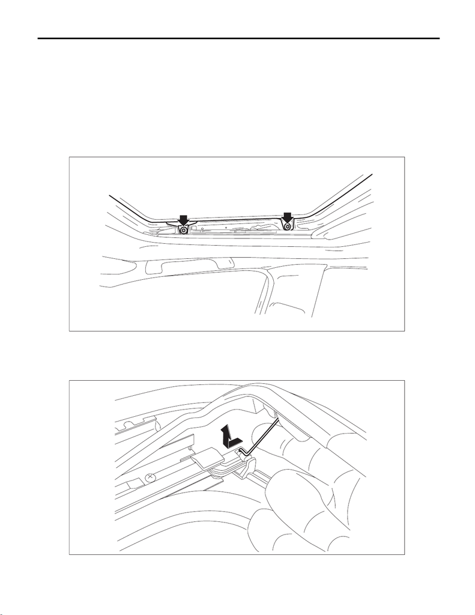

SR-7

Glass Lid

SUNROOF/T-TOP/CONVERTIBLE TOP (SUNROOF)

4. Glass Lid

A: REMOVAL

1. GLASS LID

CAUTION:

Be careful not to damage the lid assembly - sunroof.

1) Completely close the lid assembly - sunroof, and open the sunshade assembly.

2) Remove the lid assembly - sunroof.

Preparation tool:

TORX

®

T25

2. DEFLECTOR ASSEMBLY

1) Open the lid assembly - sunroof and the sunshade assembly.

2) Remove the deflector assembly - sunroof.

(1) Remove the spring from the rail assembly - sunroof.

SR-00187

SR-00210

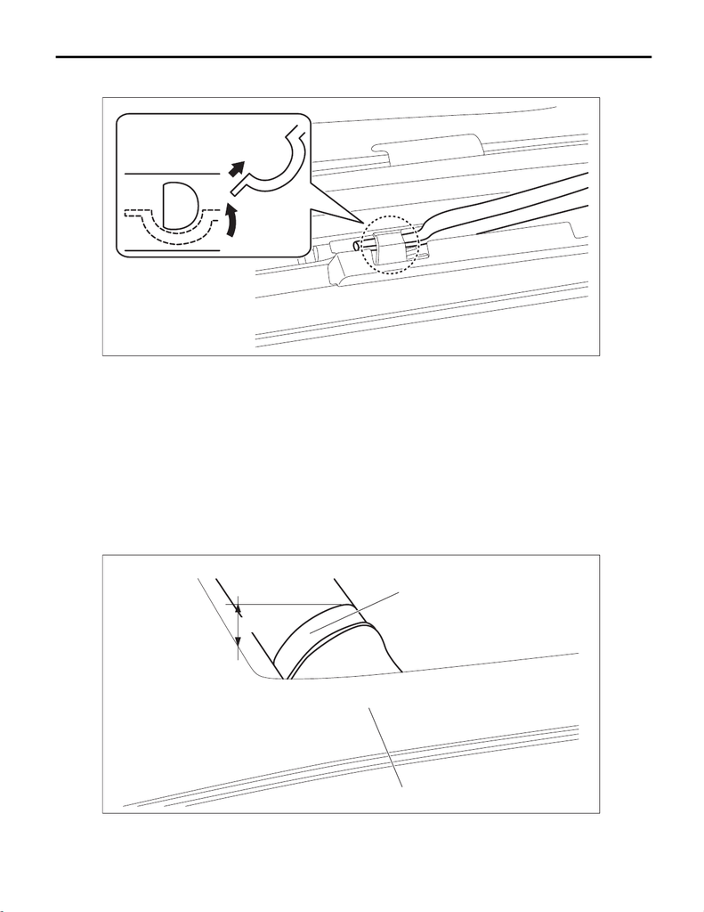

SR-8

Glass Lid

SUNROOF/T-TOP/CONVERTIBLE TOP (SUNROOF)

(2) While lifting up the deflector assembly - sunroof, remove the deflector assembly - sunroof from the

hook on the rail assembly - sunroof.

B: INSTALLATION

1. GLASS LID

1) Using a new TORX

®

bolt, install the lid assembly - sunroof.

Tightening torque:

4.5 N·m (0.5 kgf-m, 3.3 ft-lb)

2) Perform the open/close operation checks for the glass lid.

3) Check the height of the lid assembly - sunroof and the roof panel, and perform adjustment when there is

a difference between up and down, and left and right. <Ref. to SR-9, ADJUSTMENT, Glass Lid.>

2. DEFLECTOR

1) Install the deflector assembly - sunroof.

2) After installation, measure the height from the roof panel when deflector assembly - sunroof is activated.

(a) 14 mm (0.55 in) (b) Deflector ASSY - sunroof (c) Roof panel

SR-00211

SR-00212

(c)

(b)

(a)

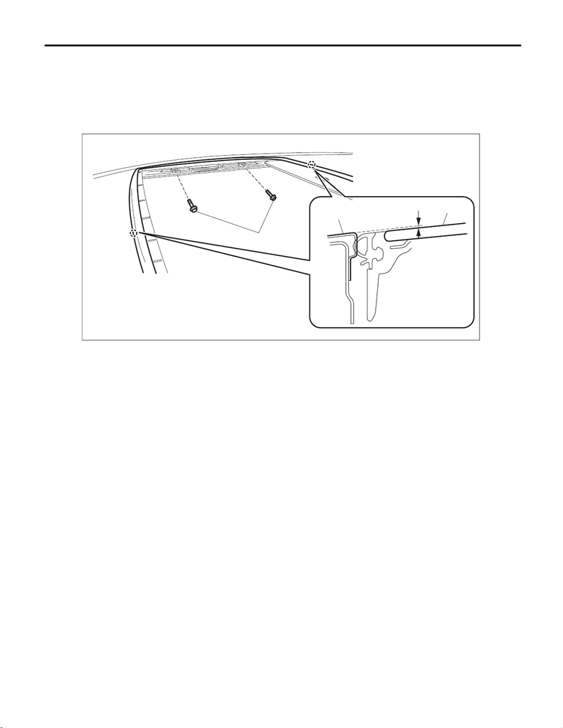

SR-9

Glass Lid

SUNROOF/T-TOP/CONVERTIBLE TOP (SUNROOF)

C: ADJUSTMENT

1) Adjust the height of the lid assembly - sunroof and the roof panel.

2) Loosen the lid assembly - sunroof mounting bolts (A), and then adjust the height by moving the lid assem-

bly - sunroof side.

Lid assembly - sunroof height difference L:

Lid assembly - sunroof to Roof panel: 0.7

±

1.0 mm (0.03

±

0.04 in)

Tightening torque:

4.5 N·m (0.5 kgf-m, 3.3 ft-lb)

(1) Roof panel (2) Lid ASSY - sunroof

SR-00193

(A)

(1)

L

(2)

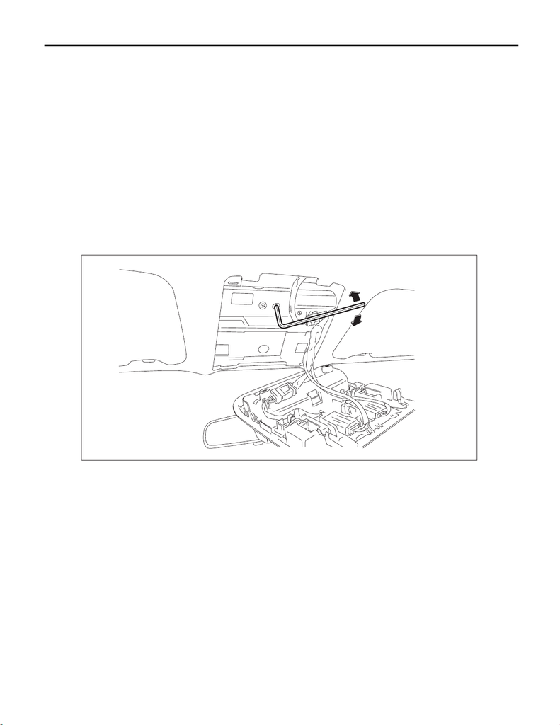

SR-10

Glass Lid

SUNROOF/T-TOP/CONVERTIBLE TOP (SUNROOF)

D: FORCED DRIVE

If the lid assembly - sunroof does not operate or the motor assembly is not supplied with power, move the lid

assembly - sunroof using the hexagon wrench.

Preparation tool:

Hexagon wrench: width across flat 4 mm (0.16 in)

CAUTION:

After a forced operation, make sure to perform an initialize operation. <Ref. to SR-6, INITIALIZE OP-

ERATION, OPERATION, Sunroof Control System.>

1) Remove the light assembly - map. <Ref. to LI-60, REMOVAL, Spot Map Light.>

2) Insert the hexagon wrench securely until it touches the motor shaft end.

3) Turn the hexagon wrench, and move the lid assembly - sunroof.

• Turning right, the lid assembly - sunroof opens.

• Turning left, the lid assembly - sunroof closes.

CAUTION:

Be careful not to damage the adjacent parts with the rod end when moving the lid assembly - sunroof

with the hexagon wrench.

SR-00194